# TP Forêts aléatoires

M2 SITIS

Author

Robin Genuer

Published

February 1, 2023

# 1 Chargement des données et packages

Recharger les données `spam` à l’aide de la commande suivante :

```r
data(spam, package = "kernlab")
```

Charger le package `randomForest` ou l’installer puis le charger le cas échéant, puis consulter l’aide de la fonction `randomForest()` :

```r
install.packages("randomForest")
```

```r
library(randomForest)
help(randomForest)
```

Créer un objet `n` contenant le nombre d’individus, et `p` le nombre de variables.

```r
n <- nrow(spam)
p <- ncol(spam) - 1
```

# 2 Bagging

Créer un prédicteur du Bagging, nommé `bag`, avec arbres non-élagués à l’aide de la fonction `randomForest()`. Dans un premier temps, on conservera le nombre d’arbres par défaut (500). Noter son erreur OOB (donné directement en sortie).

```r
bag <- randomForest(type~., spam, mtry=p)
bag
```

```
Call:
 randomForest(formula = type ~ ., data = spam, mtry = p)
               Type of random forest: classification
                     Number of trees: 500
No. of variables tried at each split: 57

        OOB estimate of  error rate: 5.24%
Confusion matrix:
        nonspam spam class.error
nonspam    2681  107  0.03837877
spam        134 1679  0.07391065
```

# 3 RF-RI avec valeurs par défaut

Faire de même avec `rf` un prédicteur des forêts aléatoires, où le nombre de variables sélectionnées à chaque noeud est laissé à sa valeur par défaut ($\sqrt{p}$ ici, car on est en classification). Noter son erreur OOB et commenter.

```r
rf <- randomForest(type~., spam)
rf
```

```
Call:
 randomForest(formula = type ~ ., data = spam)
               Type of random forest: classification
                     Number of trees: 500
No. of variables tried at each split: 7

        OOB estimate of  error rate: 4.69%
Confusion matrix:
        nonspam spam class.error
nonspam    2705   83  0.02977044
spam        133 1680  0.07335907
```

```r
# Remarque : la fonction randomForest() accepte aussi une syntaxe du type
# "x=, y=", où on renseigne les variables d'entrée et la variable de sortie :
x <- spam[, -58]
y <- spam$type
randomForest(x, y)
```

```
Call:
 randomForest(x = x, y = y)
               Type of random forest: classification
                     Number of trees: 500
No. of variables tried at each split: 7

        OOB estimate of  error rate: 4.59%
Confusion matrix:
        nonspam spam class.error
nonspam    2706   82  0.02941176
spam        129 1684  0.07115279
```

Appliquer la fonction `plot()` à l’objet de classe `randomForest` résultat.

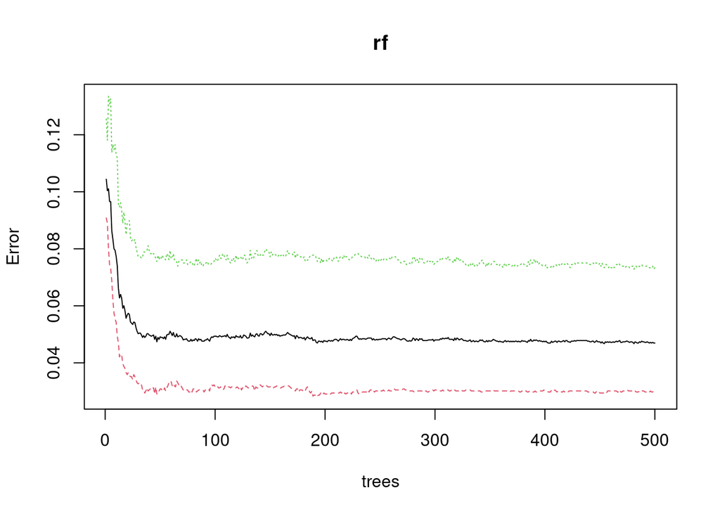

```r
plot(rf)
```

# 4 Réglage des paramètres

## 4.1 Nombre d’arbres

Pour le paramètre du nombre d’arbres, il suffit de s’assurer que celui-ci n’est pas trop petit. Il faut dans le `plot(rf)` regarder si l’erreur OOB s’est bien stabilisée. Si on observe une courbe encore décroissante, il faut augmenter le nombre d’arbres.

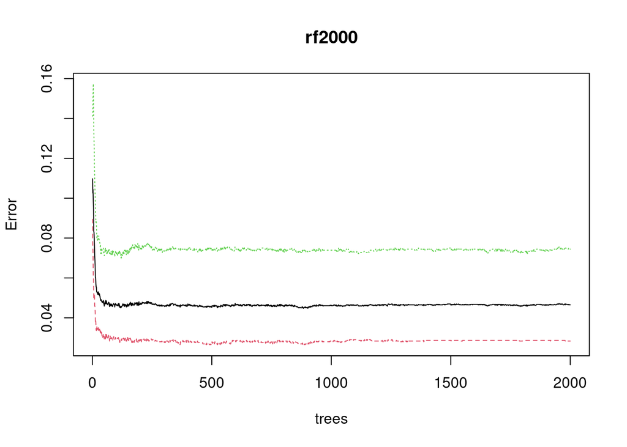

```r
rf2000 <- randomForest(x, y, ntree = 2000)
plot(rf2000)
```

## 4.2 Nombre de variables sélectionnées à chaque noeud

Régler le paramètre du nombre de variables sélectionnées à chaque noeud au mieux, en laissant le nombre d’arbres par défaut.

```r
nbvars <- 1:p
oobs_mtry <- rep(NA, length(nbvars))
for (nbv in seq_along(nbvars)){
  rf <- randomForest(x, y, mtry = nbvars[nbv])
  oobs_mtry[nbv] <- rf$err.rate[500, "OOB"]
}
```

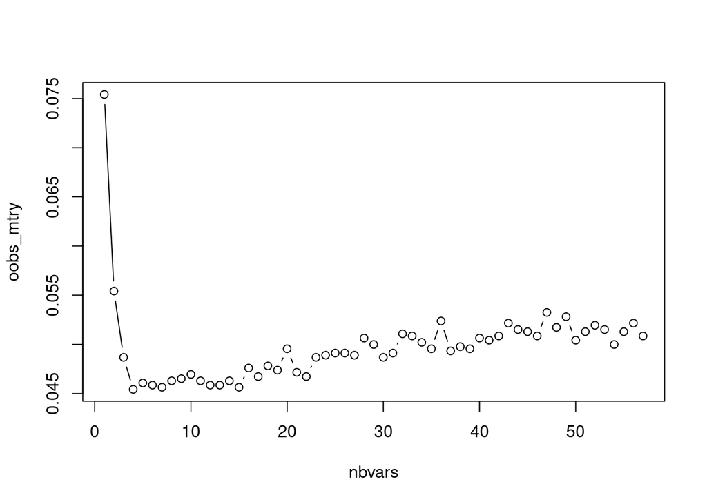

```r
plot(cbind(nbvars, oobs_mtry), type = "b")
```

```r
nbvaropt <- nbvars[which.min(oobs_mtry)]
nbvaropt
```

```
[1] 4
```

```r
oobs_mtry[which.min(oobs_mtry)]
```

```
[[1]]
       OOB
0.04542491
```

```r
# Remarque : Pour stabiliser notre choix (il est ici un peu instable car il
# existe une "petite" variabilité des forêts), on pourrait calculer la
# moyenne de l'erreur OOB sur plusieurs forêts, par exemple comme ceci sur 10
# forêts :
oob_rep <- replicate(10, randomForest(x, y)$err.rate[500, "OOB"])
mean(oob_rep)
```

```
[1] 0.04514236
```

```r
# Mais bien entendu, le temps de calcul est d'autant plus augmenté qu'on fait de
# répétitions...
```

# 5 Contraintes sur le développement des arbres

1. Construire une forêt aléatoire d’arbres à deux feuilles.

```r
rf_2f <- randomForest(x, y, maxnodes = 2)
rf_2f
```

```
Call:
 randomForest(x = x, y = y, maxnodes = 2)
               Type of random forest: classification
                     Number of trees: 500
No. of variables tried at each split: 7

        OOB estimate of  error rate: 15.47%
Confusion matrix:
        nonspam spam class.error
nonspam    2758   30   0.0107604
spam        682 1131   0.3761721
```

2. Construie une forêt aléatoire dont les arbres ne contiennent aucune feuille possédant moins de 50 observations.

```r
rf_size_50 <- randomForest(x, y, nodesize = 50)
```

3. Construire une forêt aléatoire de 5 arbres, dont chaque arbre a au plus 8 feuilles.

   ```r
   rf_15f <- randomForest(x, y, ntree = 5, maxnodes = 8)
   ```

   Regarder en détails l’objet `rf$forest` et essayer de comprendre son contenu.

# 6 Importance des variables

1. Construire une forêt aléatoire calculant l’importance des variables.

```r
rf_imp <- randomForest(x, y, importance = TRUE)
```

2. Appliquer la fonction `varImpPlot()` pour visualiser les scores d’importance obtenus.

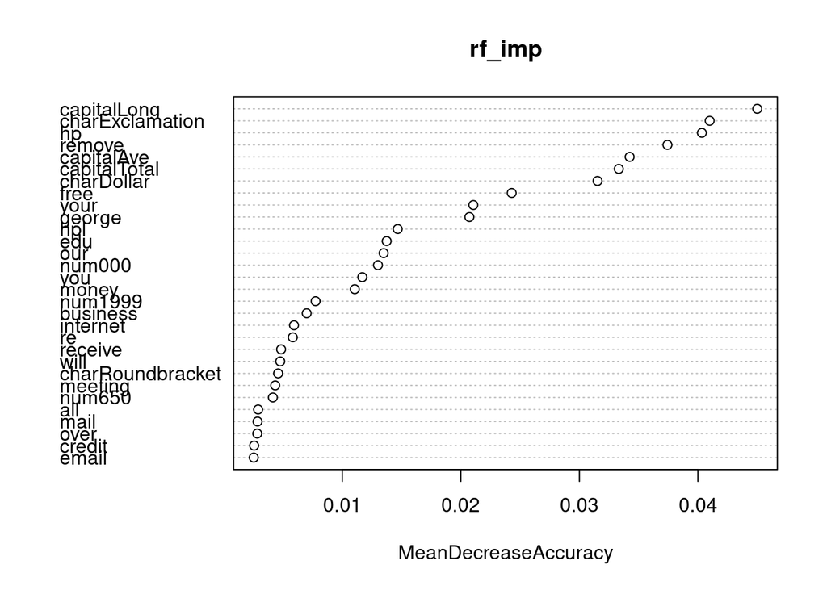

```r
varImpPlot(rf_imp, scale = FALSE, type = 1)
```